# Tidying and joining data

Andrew Ba Tran

This is from the [third chapter](https://learn.r-journalism.com/en/wrangling/tidyr_joins/tidyr-joins/) of [learn.r-journalism.com](https://learn.r-journalism.com/).

We’re going to learn a couple new concepts while digging through this **murders** database: **tidyr** and joins. I’ve mentioned tidy data before briefly, and we’re going to get into it in this section.

Do you still have the **murders** data frame in the environment?

If not, run the command below:

```r
source("import_murders.R")
```

# tidyr

Data can be messy but there’s an ideal structure for how to stack your data.

And that’s with

1. Each **variable** is in its own **column**
2. Each **case** is in its own **row**
3. Each **value** is in its own **cell**

```r
murders %>%
  group_by(State, Year) %>%
  summarize(cases=n(), solved=sum(Solved_value))
```

```
## # A tibble: 2,066 x 4
## # Groups:   State [?]
##    State   Year cases solved
##    <fct>  <dbl> <int>  <dbl>
##  1 Alaska  1976    47     37
##  2 Alaska  1977    47     32
##  3 Alaska  1978    50     44
##  4 Alaska  1979    51     35
##  5 Alaska  1980    47     37
##  6 Alaska  1981    69     62
##  7 Alaska  1982    75     47
##  8 Alaska  1983    74     63
##  9 Alaska  1984    52     45
## 10 Alaska  1985    50     36
## # ... with 2,056 more rows
```

This type of data structure is easy to mutate and manipulate

```r
murders %>%
  group_by(State, Year) %>%
  summarize(cases=n(), solved=sum(Solved_value)) %>%
  mutate(percent=solved/cases*100)
```

```
## # A tibble: 2,066 x 5
## # Groups:   State [51]
##    State   Year cases solved percent
##    <fct>  <dbl> <int>  <dbl>   <dbl>
##  1 Alaska  1976    47     37    78.7
##  2 Alaska  1977    47     32    68.1
##  3 Alaska  1978    50     44    88
##  4 Alaska  1979    51     35    68.6
##  5 Alaska  1980    47     37    78.7
##  6 Alaska  1981    69     62    89.9
##  7 Alaska  1982    75     47    62.7
##  8 Alaska  1983    74     63    85.1
##  9 Alaska  1984    52     45    86.5
## 10 Alaska  1985    50     36    72
## # ... with 2,056 more rows
```

On the other hand, the data below is **not** tidy.

```
## # A tibble: 6,198 x 4
## # Groups:   State [51]
##    State   Year type        n
##    <fct>  <dbl> <chr>   <dbl>
##  1 Alaska  1976 solved   37
##  2 Alaska  1976 percent  78.7
##  3 Alaska  1976 cases    47
##  4 Alaska  1977 solved   32
##  5 Alaska  1977 percent  68.1
##  6 Alaska  1977 cases    47
##  7 Alaska  1978 solved   44
##  8 Alaska  1978 percent  88
##  9 Alaska  1978 cases    50
## 10 Alaska  1979 solved   35
## # ... with 6,188 more rows
```

There are too many differing types– *solved*, *percent*, and *cases* should not be on the same column.

But sometimes you’ll get data from sources this way or your analysis will generate data like that.

Let’s take a look at the **murders** database again.

Look over the data frame and consider all the variables (columns) or dig through the [data dictionary](https://www.dropbox.com/s/lo6tgo8nnbpqeru/MAPdefinitionsSHR.pdf?dl=1).

With the variables we have, what questions can we ask of it?

- **MSA_label** are Metropolitan Statistical Areas
- **VicRace_label** are races
  - Note: This requires a huge grain of salt because what happens when you run `murders %>% group_by(VicRace_label) %>% count()`?
  - Answer: There is no label for “Hispanic” victims
- **Solved_label** are whether not the cases were solved

With this data, we could figure out which metro areas are solving murders at a higher rate for particular races than others. Sort of like for [Where Killings Go Unsolved](https://www.washingtonpost.com/graphics/2018/investigations/where-murders-go-unsolved/) from The Washington Post. The data we’re working with isn’t as specific as the Post’s. They can identify clusters of murders down the the specific location because they have latitude and longitude data. We have data that’s generalized to counties and metro areas.

But it’s still enough for us to get started to identify cities where it’s a problem because unsolved killings can perpetuate cycles of violence in low-arrest areas.

We’re going to use the **DT** package to help work through this data. It brings in the [DataTables](https://www.google.com/search?q=datatables+plugin&rlz=1C5CHFA_enUS749US749&oq=datatables+plug&aqs=chrome.0.69i59j69i57j0l4.3719j0j1&sourceid=chrome&ie=UTF-8) jquery plug-in that makes it easier to interact with tables in R.

Let’s start broadly by finding the percent breakdown of solving cases in each metro area over the past 10 years.

```r
# If you don't have DT installed yet, uncomment the line below and run it
#install.packages("DT")
library(DT)

unsolved <- murders %>%
  group_by(MSA_label, Solved_label) %>%
  filter(Year>2008) %>%
  summarize(cases=n())

datatable(unsolved)
```

|  | MSA_label | Solved_label | cases |
| --- | --- | --- | --- |
| 1 | Abilene, TX | No | 3 |
| 2 | Abilene, TX | Yes | 51 |
| 3 | Akron, OH | No | 62 |
| 4 | Akron, OH | Yes | 202 |
| 5 | Albany, GA | No | 25 |
| 6 | Albany, GA | Yes | 70 |
| 7 | Albany-Schenectady-Troy, NY | No | 41 |
| 8 | Albany-Schenectady-Troy, NY | Yes | 143 |
| 9 | Albuquerque, NM | No | 79 |
| 10 | Albuquerque, NM | Yes | 423 |

[output cut: 776 more lines]

Alright, so far, we’ve counted up the cases and the instances of them being solved or not.

Let’s use the `mutate()` function to calculate percents.

```r
murders %>%
  group_by(MSA_label, Solved_label) %>%
  filter(Year>2008) %>%
  summarize(cases=n()) %>%
  mutate(percent=cases/sum(cases)*100) %>%
  datatable() # piping to the datatable function this time because it's more efficient
```

|  | MSA_label | Solved_label | cases | percent |
| --- | --- | --- | --- | --- |
| 1 | Abilene, TX | No | 3 | 5.55555555555556 |
| 2 | Abilene, TX | Yes | 51 | 94.4444444444444 |
| 3 | Akron, OH | No | 62 | 23.4848484848485 |
| 4 | Akron, OH | Yes | 202 | 76.5151515151515 |
| 5 | Albany, GA | No | 25 | 26.3157894736842 |
| 6 | Albany, GA | Yes | 70 | 73.6842105263158 |
| 7 | Albany-Schenectady-Troy, NY | No | 41 | 22.2826086956522 |
| 8 | Albany-Schenectady-Troy, NY | Yes | 143 | 77.7173913043478 |
| 9 | Albuquerque, NM | No | 79 | 15.7370517928287 |
| 10 | Albuquerque, NM | Yes | 423 | 84.2629482071713 |

[output cut: 776 more lines]

Getting closer, and though this data isn’t untidy, it’s not that easy to present.

What if your editor wanted to see which major metro areas ranked highest for percent of unsolved cases?

That’s easy for this data frame.

- Filter out cases where there are less than 10 cases to eliminate smaller metro areas
- Filter only the rows with “No” in the **Solved_label** column
- Drop the **Solved_label** because it’s redundant
- Arrange percent unsolved column from high to low

```r
murders %>%
  group_by(MSA_label, Solved_label) %>%
  filter(Year>2008) %>%
  summarize(cases=n()) %>%
  filter(sum(cases)>10) %>%
  mutate(percent=cases/sum(cases)*100) %>%
  filter(Solved_label=="No") %>%
  select(Metro=MSA_label, cases_unsolved=cases, percent_unsolved=percent) %>%
  arrange(desc(percent_unsolved)) %>%
  datatable()
```

|  | Metro | cases_unsolved | percent_unsolved |
| --- | --- | --- | --- |
| 1 | Salinas, CA | 255 | 66.0621761658031 |
| 2 | Chicago-Naperville-Joliet, IL-IN-WI | 3102 | 64.0644361833953 |
| 3 | Buffalo-Niagara Falls, NY | 284 | 59.1666666666667 |
| 4 | Montgomery, AL | 185 | 56.4024390243902 |
| 5 | Flint, MI | 251 | 55.902004454343 |
| 6 | New Orleans-Metairie-Kenner, LA | 1053 | 53.6150712830957 |
| 7 | San Francisco-Oakland-Fremont, CA | 1137 | 53.006993006993 |
| 8 | Baltimore-Towson, MD | 1266 | 52.8822055137845 |
| 9 | Stockton, CA | 302 | 52.7972027972028 |
| 10 | Trenton-Ewing, NJ | 111 | 51.8691588785047 |

[output cut: 360 more lines]

Interesting.

Chicago is unsurprising but I was not expecting Salinas, California.

Let’s keep going.

What happens if we dis aggregate the data by seeing if clearance rates are different depending on the race of the victim in those metro areas.

Let’s start out by adding **VicRace_label** into the `group_by()` code and figure out the percents.

```r
murders %>%
  group_by(MSA_label, VicRace_label, Solved_label) %>%
  filter(Year>2008) %>%
  summarize(cases=n()) %>%
  mutate(percent=cases/sum(cases, na.rm=T)*100) %>%
  datatable()
```

|  | MSA_label | VicRace_label | Solved_label | cases | percent |
| --- | --- | --- | --- | --- | --- |
| 1 | Abilene, TX | Black | No | 2 | 15.3846153846154 |
| 2 | Abilene, TX | Black | Yes | 11 | 84.6153846153846 |
| 3 | Abilene, TX | White | No | 1 | 2.4390243902439 |
| 4 | Abilene, TX | White | Yes | 40 | 97.5609756097561 |
| 5 | Akron, OH | Asian or Pacific Islander | No | 1 | 100 |
| 6 | Akron, OH | Black | No | 54 | 35.7615894039735 |
| 7 | Akron, OH | Black | Yes | 97 | 64.2384105960265 |
| 8 | Akron, OH | Unknown | Yes | 1 | 100 |
| 9 | Akron, OH | White | No | 7 | 6.30630630630631 |
| 10 | Akron, OH | White | Yes | 104 | 93.6936936936937 |

[output cut: 2259 more lines]

Once again, your editor doesn’t care about your tidy data.

Give them something they can sort quickly to find a story.

Let’s clean it up like with the other data frame on metro areas.

```r
# Also, we're going to round the percents with the round() function

race <- murders %>%
  group_by(MSA_label, VicRace_label, Solved_label) %>%
  filter(Year>2008) %>%
  summarize(cases=n()) %>%
  mutate(percent=cases/sum(cases)*100) %>%
  mutate(percent=round(percent, digits=2)) %>%
  filter(Solved_label=="No") %>%
  select(Metro=MSA_label, VicRace_label, cases_unsolved=cases, percent_unsolved=percent) %>%
  arrange(desc(percent_unsolved))

datatable(race)
```

|  | Metro | VicRace_label | cases_unsolved | percent_unsolved |
| --- | --- | --- | --- | --- |
| 1 | Akron, OH | Asian or Pacific Islander | 1 | 100 |
| 2 | Bakersfield, CA | Asian or Pacific Islander | 3 | 100 |
| 3 | Billings, MT | Unknown | 1 | 100 |
| 4 | Brownsville-Harlingen, TX | Unknown | 1 | 100 |
| 5 | Cape Coral-Fort Myers, FL | Unknown | 1 | 100 |
| 6 | Charleston-North Charleston, SC | Unknown | 1 | 100 |
| 7 | Cleveland-Elyria-Mentor, OH | American Indian or Alaskan Native | 1 | 100 |
| 8 | Corpus Christi, TX | Unknown | 1 | 100 |
| 9 | Dalton, GA | Black | 1 | 100 |
| 10 | Durham, NC | American Indian or Alaskan Native | 1 | 100 |

[output cut: 913 more lines]

Okay, we’re getting closer. But the race values are throwing off the sorting. We need to transform this tall data and make it wide.

## spread()

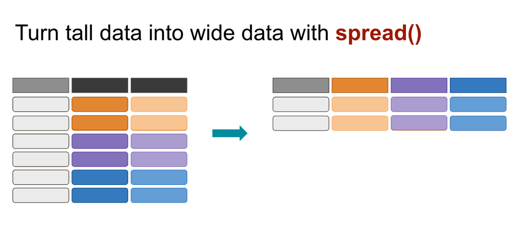

The `spread()` function in the **tidyr** package moves values into column names.

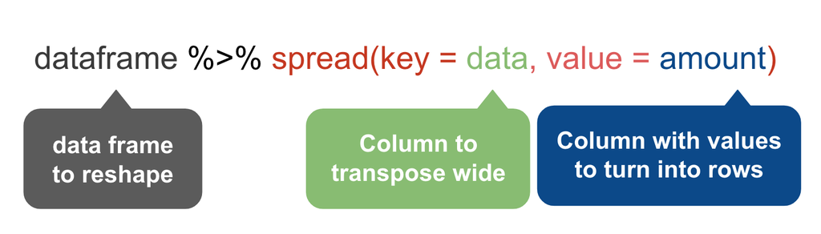

We want to move the values of the **VicRace_label** and turn them into columns while preserving the values in **percent_unsolved**

```r
# We've saved our previous steps into the "race" dataframe
# So we can continue our steps because they've been saved

race %>%
  spread(VicRace_label, percent_unsolved) %>%
  datatable()
```

|  | Metro | cases_unsolved | Asian or Pacific Islander | Black | American Indian or Alaskan Native | Unknown | White |
| --- | --- | --- | --- | --- | --- | --- | --- |
| 1 | Abilene, TX | 1 |  |  |  |  | 2.44 |
| 2 | Abilene, TX | 2 |  | 15.38 |  |  |  |
| 3 | Akron, OH | 1 | 100 |  |  |  |  |
| 4 | Akron, OH | 7 |  |  |  |  | 6.31 |
| 5 | Akron, OH | 54 |  | 35.76 |  |  |  |
| 6 | Albany, GA | 3 |  |  |  |  | 15.79 |
| 7 | Albany, GA | 22 |  | 29.33 |  |  |  |
| 8 | Albany-Schenectady-Troy, NY | 3 |  |  |  | 33.33 |  |
| 9 | Albany-Schenectady-Troy, NY | 4 | 57.14 |  |  |  |  |
| 10 | Albany-Schenectady-Troy, NY | 10 |  |  |  |  | 12.35 |

[output cut: 870 more lines]

Oh no!

What happened!?

See, `spread()` can only turn one tall column wide at a time.

We need to drop the **cases_unsolved** column in order for this to transpose correctly.

That’s fine, though. We’ll come back for it later on.

Let’s try again.

```r
# This time we'll drop the cases_unsolved column before spreading

race_percent <- race %>%
  select(-cases_unsolved) %>%
  spread(VicRace_label, percent_unsolved)

datatable(race_percent)
```

|  | Metro | Asian or Pacific Islander | Black | American Indian or Alaskan Native | Unknown | White |
| --- | --- | --- | --- | --- | --- | --- |
| 1 | Abilene, TX |  | 15.38 |  |  | 2.44 |
| 2 | Akron, OH | 100 | 35.76 |  |  | 6.31 |
| 3 | Albany, GA |  | 29.33 |  |  | 15.79 |
| 4 | Albany-Schenectady-Troy, NY | 57.14 | 27.59 |  | 33.33 | 12.35 |
| 5 | Albuquerque, NM |  | 25.49 | 22.22 | 10.53 | 14.36 |
| 6 | Alexandria, LA |  | 12.5 |  |  | 5.26 |
| 7 | Allentown-Bethlehem-Easton, PA-NJ |  | 40.74 |  |  | 22.92 |
| 8 | Altoona, PA |  | 25 |  |  | 10.53 |
| 9 | Amarillo, TX |  | 10 |  |  | 8.24 |
| 10 | Anchorage, AK | 12 | 13.89 | 20.29 |  | 13.21 |

[output cut: 368 more lines]

## gather()

Alright, we’ve performed some magic here but making something disappear isn’t enough. We have to bring it back.

What if you have data that’s in a wide format and want to make it tall for analysis or visualization purposes?

Three reasons why you should attempt to structure your data in long (tall) form:

- If you have many columns, it’s difficult to summarize it at a glance and see if there are any mistakes in the data.
- Key-value pairs facilitates conceptual clarity
- Long-form datasets are required for graphing and advanced statistical analysis

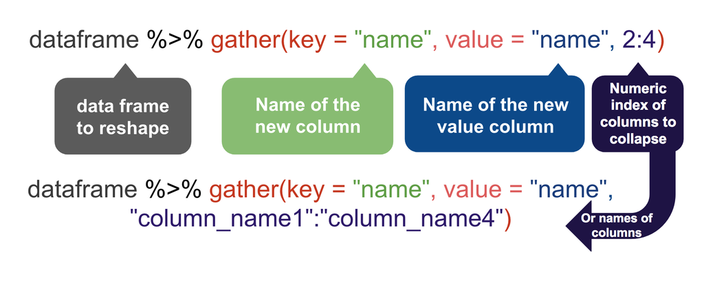

The first two arguments specify a key-value pair: *race* is the key and *percent_unsolved* the value. The third argument specifies which variables in the original data to convert into the key-value combination (in this case, all variables from *`Asian or Pacific Islander`* to *White*).

```r
# So 2:6 represents the column index, or where the columns are in the data frame-- so columns 2 through 6
race_percent %>%
  gather("Race", "Percent_Unsolved", 2:6) %>%
  arrange(desc(Metro)) %>%
  datatable()
```

|  | Metro | Race | Percent_Unsolved |
| --- | --- | --- | --- |
| 1 | Rural Wyoming | Asian or Pacific Islander |  |
| 2 | Rural Wyoming | Black |  |
| 3 | Rural Wyoming | American Indian or Alaskan Native | 12.5 |
| 4 | Rural Wyoming | Unknown |  |
| 5 | Rural Wyoming | White | 10.94 |
| 6 | Rural Wisconsin | Asian or Pacific Islander |  |
| 7 | Rural Wisconsin | Black |  |
| 8 | Rural Wisconsin | American Indian or Alaskan Native |  |
| 9 | Rural Wisconsin | Unknown |  |
| 10 | Rural Wisconsin | White | 0.71 |

[output cut: 1880 more lines]

```r
## Instead of numbers you can use column names
## This is a reminder that to reference column names with spaces, you have to use the ` back tick around the column names

race_percent %>%
  gather("Race", "Percent_Unsolved", `Asian or Pacific Islander`:White) %>%
  arrange(desc(Metro)) %>%
  datatable()
```

|  | Metro | Race | Percent_Unsolved |
| --- | --- | --- | --- |
| 1 | Rural Wyoming | Asian or Pacific Islander |  |
| 2 | Rural Wyoming | Black |  |
| 3 | Rural Wyoming | American Indian or Alaskan Native | 12.5 |
| 4 | Rural Wyoming | Unknown |  |
| 5 | Rural Wyoming | White | 10.94 |
| 6 | Rural Wisconsin | Asian or Pacific Islander |  |
| 7 | Rural Wisconsin | Black |  |
| 8 | Rural Wisconsin | American Indian or Alaskan Native |  |
| 9 | Rural Wisconsin | Unknown |  |
| 10 | Rural Wisconsin | White | 0.71 |

[output cut: 1880 more lines]

Okay, we’ve digressed long enough.

Let’s get back to our data analysis.

```r
race_percent %>% arrange(desc(Black)) %>% datatable()
```

|  | Metro | Asian or Pacific Islander | Black | American Indian or Alaskan Native | Unknown | White |
| --- | --- | --- | --- | --- | --- | --- |
| 1 | Dalton, GA |  | 100 |  |  | 4.55 |
| 2 | McAllen-Edinburg-Mission, TX |  | 100 |  | 100 | 21.57 |
| 3 | Madera, CA | 100 | 85.71 |  |  | 43.18 |
| 4 | Buffalo-Niagara Falls, NY |  | 69.69 | 33.33 | 33.33 | 29.91 |
| 5 | Chicago-Naperville-Joliet, IL-IN-WI | 33.33 | 67.78 | 50 | 81.58 | 52.58 |
| 6 | Salinas, CA | 25 | 66.67 |  | 100 | 67.32 |
| 7 | Weirton-Steubenville, WV-OH |  | 66.67 |  |  | 9.09 |
| 8 | Boston-Cambridge-Quincy, MA-NH | 4.35 | 65.05 | 33.33 | 25.71 | 28.18 |
| 9 | Pittsburgh, PA |  | 64.5 |  | 50 | 24.36 |
| 10 | Omaha-Council Bluffs, NE-IA |  | 61.31 | 16.67 |  | 14.38 |

[output cut: 368 more lines]

See anything interesting?

We’ve arranged the data frame by descending percent unsolved this time.

Dalton, GA and McAllen-Edinburg-Mission, TX have 100 percent unsolved rates for Black victims.

That’s a big deal, right?

Well, that depends on how many total victims there were– which this table doesn’t provide.

We used to have that data but we had to get rid of it when we used `spread()` on it a few steps earlier.

Aha, we stored it as `race` so it should still be in your environment.

Let’s copy and paste the code from above to to restore it (yay, reproducibility!).

```r
race_percent <- race %>%
  select(-cases_unsolved) %>%
  spread(VicRace_label, percent_unsolved)

datatable(race_percent)
```

|  | Metro | Asian or Pacific Islander | Black | American Indian or Alaskan Native | Unknown | White |
| --- | --- | --- | --- | --- | --- | --- |
| 1 | Abilene, TX |  | 15.38 |  |  | 2.44 |
| 2 | Akron, OH | 100 | 35.76 |  |  | 6.31 |
| 3 | Albany, GA |  | 29.33 |  |  | 15.79 |
| 4 | Albany-Schenectady-Troy, NY | 57.14 | 27.59 |  | 33.33 | 12.35 |
| 5 | Albuquerque, NM |  | 25.49 | 22.22 | 10.53 | 14.36 |
| 6 | Alexandria, LA |  | 12.5 |  |  | 5.26 |
| 7 | Allentown-Bethlehem-Easton, PA-NJ |  | 40.74 |  |  | 22.92 |
| 8 | Altoona, PA |  | 25 |  |  | 10.53 |
| 9 | Amarillo, TX |  | 10 |  |  | 8.24 |
| 10 | Anchorage, AK | 12 | 13.89 | 20.29 |  | 13.21 |

[output cut: 368 more lines]

So it looks like we dropped **cases_unsolved** and kept **percent_unsolved** for spreading.

Let’s reverse that and drop **percent_unsolved** and keep the **cases_unsolved** instead.

Once again, we can copy and paste the code we used and make a little adjustment in the `select()` and `spread()` functions:

```r
race_cases <- race %>%
  select(-percent_unsolved) %>%
  spread(VicRace_label, cases_unsolved)

datatable(race_cases)
```

|  | Metro | Asian or Pacific Islander | Black | American Indian or Alaskan Native | Unknown | White |
| --- | --- | --- | --- | --- | --- | --- |
| 1 | Abilene, TX |  | 2 |  |  | 1 |
| 2 | Akron, OH | 1 | 54 |  |  | 7 |
| 3 | Albany, GA |  | 22 |  |  | 3 |
| 4 | Albany-Schenectady-Troy, NY | 4 | 24 |  | 3 | 10 |
| 5 | Albuquerque, NM |  | 13 | 8 | 2 | 56 |
| 6 | Alexandria, LA |  | 7 |  |  | 1 |
| 7 | Allentown-Bethlehem-Easton, PA-NJ |  | 22 |  |  | 33 |
| 8 | Altoona, PA |  | 1 |  |  | 2 |
| 9 | Amarillo, TX |  | 2 |  |  | 7 |
| 10 | Anchorage, AK | 3 | 5 | 14 |  | 14 |

[output cut: 368 more lines]

The original problem was that the **race_percent** did not have the contextual information of how many cases there were to determine if the percents listed were significant or not.

We’ve created two new data frames **race_percent** and **race_cases** and they each have what we need.

So let’s bring those two together.

# Joining

A join combines two data sets by adding the columns of one data set alongside the columns of the other, usually some of the rows of the second data set along with some rows of the first data set.

A successful join requires something consistent between two data sets to match on: keys.

What are the keys that the *race_percent **and** race_cases** can join on? Take a look.

What’s consistent about each of them? Column names, sure.

But also the Metro areas.

The **dplyr** package has quite a few functions we can use.

Let’s start with:

## left_join()

In all joins, you pass two variables: the first one is the target data frame and the second one is the data frame you’re bringing over. By default the function will look to join on column names that are the same (You can join by more than one column name, by the way). You can also specify which column the columns should join by.

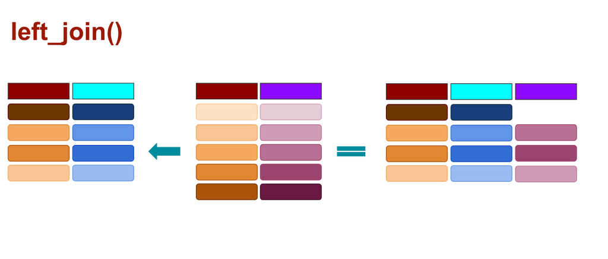

When you use `left_join()` any rows from the second data frame that doesn’t match the target data frame are dropped, as illustrated above.

Let’s try it out.

```r
# If we don't use the by variable it would match nothing because the column names are the exact same for both data frames

wide1 <- left_join(race_percent, race_cases, by="Metro")
```

```
View(wide1)
```

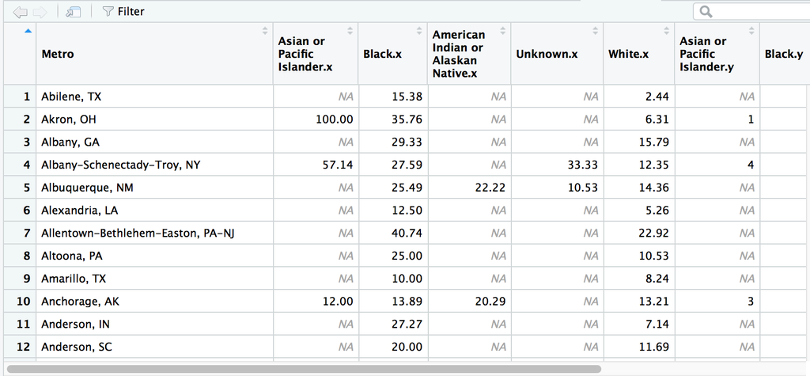

Hey, it worked! And the column names were automatically renamed to avoid duplicates.

So let’s clean it up.

We can use `select()` to rename and reorder the columns of the data frame so the race data are grouped.

Let’s also arrange the cases in descending Black unsolved percent like in one of our steps above.

```r
# Don't forget: If there are spaces in the column names, you have to use the ` back tick.

wide2 <- left_join(race_percent, race_cases, by="Metro") %>%
  select(Metro,
         `Asian cases`=`Asian or Pacific Islander.y`,
         `Asian percent`=`Asian or Pacific Islander.x`,
         `Native American cases`=`American Indian or Alaskan Native.y`,
         `Native American percent`=`American Indian or Alaskan Native.x`,
         `Black cases`=Black.y,
         `Black percent`=Black.x,
         `White cases`=White.y,
         `White percent`=White.x,
         `Unknown cases`=Unknown.y,
         `Unknown percent`=Unknown.x
         ) %>%
  arrange(desc(`Black percent`))
```

```
View(wide2)
```

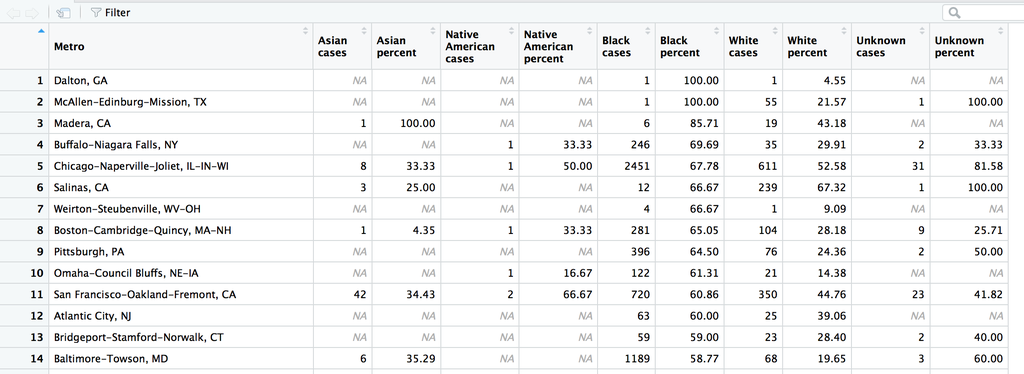

Even one row below in Chicago, the unsolved rate for Blacks and Whites is 68 and 53 percent, respectively. What’s going on in Buffalo? This might be a story worth reporting if you’re from the area or are looking for this type of disparity across the country?

I know we need to move on to learn about other ways to join data but I just wanna do a quick analysis– which is possible thanks to what you’ve already learned with **dplyr**!

Let’s just do a quick analysis with our new **wide2** data frame.

We want to find

1. Which towns have the biggest disparity in unsolved cases between Black and White victims.
2. Let’s also filter out cases, at say, 10
3. Get rid of the other columns so can focus on what we’re looking for

```r
wide2 %>%
  filter(`Black cases` >=10 & `White cases`>=10) %>%
  mutate(Black_White=`Black percent`-`White percent`) %>%
  select(Metro, `Black cases`, `White cases`, `Black percent`, `White percent`, Black_White) %>%
  arrange(desc(Black_White)) %>%
  datatable()
```

|  | Metro | Black cases | White cases | Black percent | White percent | Black_White |
| --- | --- | --- | --- | --- | --- | --- |
| 1 | Omaha-Council Bluffs, NE-IA | 122 | 21 | 61.31 | 14.38 | 46.93 |
| 2 | Pittsburgh, PA | 396 | 76 | 64.5 | 24.36 | 40.14 |
| 3 | Buffalo-Niagara Falls, NY | 246 | 35 | 69.69 | 29.91 | 39.78 |
| 4 | Baltimore-Towson, MD | 1189 | 68 | 58.77 | 19.65 | 39.12 |
| 5 | St. Louis, MO-IL | 836 | 74 | 58.38 | 21.51 | 36.87 |
| 6 | Boston-Cambridge-Quincy, MA-NH | 281 | 104 | 65.05 | 28.18 | 36.87 |
| 7 | Port St. Lucie-Fort Pierce, FL | 39 | 14 | 54.17 | 17.5 | 36.67 |
| 8 | Cape Coral-Fort Myers, FL | 73 | 36 | 54.07 | 19.46 | 34.61 |
| 9 | Bridgeport-Stamford-Norwalk, CT | 59 | 23 | 59 | 28.4 | 30.6 |
| 10 | New Orleans-Metairie-Kenner, LA | 963 | 75 | 57.84 | 27.27 | 30.57 |

[output cut: 108 more lines]

Interesting. Buffalo-Niagara Falls, NY is actually third for disparity.

Omaha-Council Bluffs, NE-IA and Pittsburgh, PA are worst.

Alright, alright, back to the joins.

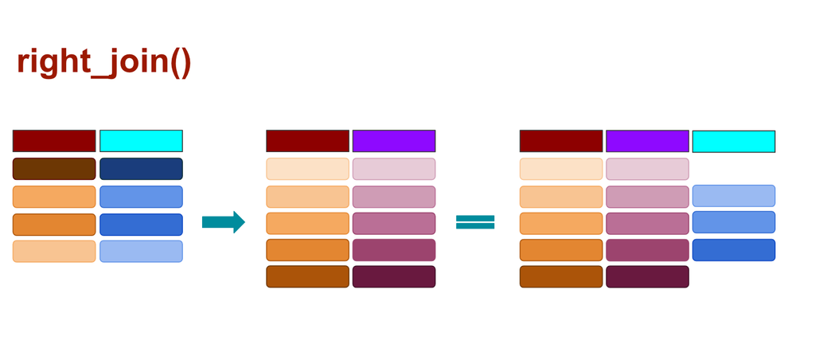

When you use `right_join()` any rows from the second data frame that doesn’t match the target data frame are kept, and those that don’t match from the original data frame are dropped, as illustrated above.

```r
left <- data.frame(company=c("Mars", "Hershey", "Cadbury",  "Mondelez", "Haribo"),
                   candy=c("Skittles", "M&Ms", "Starbar", "Toblerone", "Goldbaren"))
right <- data.frame(company=c("Hershey", "Mondelez", "Cadbury", "Mars", "Colosinas Fini"),
                    location=c("Pennsylvania", "Switzerland", "Britain", "New Jersey", "Spain"))
left
```

```
##    company     candy
## 1     Mars  Skittles
## 2  Hershey      M&Ms
## 3  Cadbury   Starbar
## 4 Mondelez Toblerone
## 5   Haribo Goldbaren
```

```r
right
```

```
##          company     location
## 1        Hershey Pennsylvania
## 2       Mondelez  Switzerland
## 3        Cadbury      Britain
## 4           Mars   New Jersey
## 5 Colosinas Fini        Spain
```

```r
# We don't have to use by="column_name" this time because both data frames only have one matching column name to join on: Company

right_join(left, right)
```

```
##          company     candy     location
## 1        Hershey      M&Ms Pennsylvania
## 2       Mondelez Toblerone  Switzerland
## 3        Cadbury   Starbar      Britain
## 4           Mars  Skittles   New Jersey
## 5 Colosinas Fini      <NA>        Spain
```

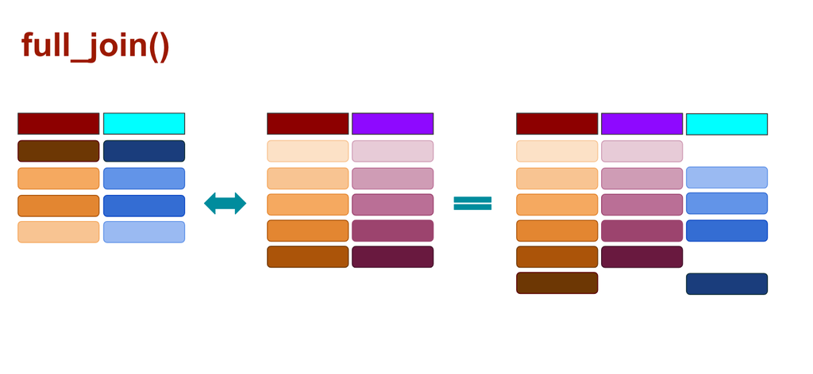

When you use `full_join()` any rows from the second data frame that doesn’t match the target data frame are kept, and so are the rows that don’t match from the original data frame, as illustrated above.

```r
full_join(left, right)
```

```
##          company     candy     location
## 1           Mars  Skittles   New Jersey
## 2        Hershey      M&Ms Pennsylvania
## 3        Cadbury   Starbar      Britain
## 4       Mondelez Toblerone  Switzerland
## 5         Haribo Goldbaren         <NA>
## 6 Colosinas Fini      <NA>        Spain
```

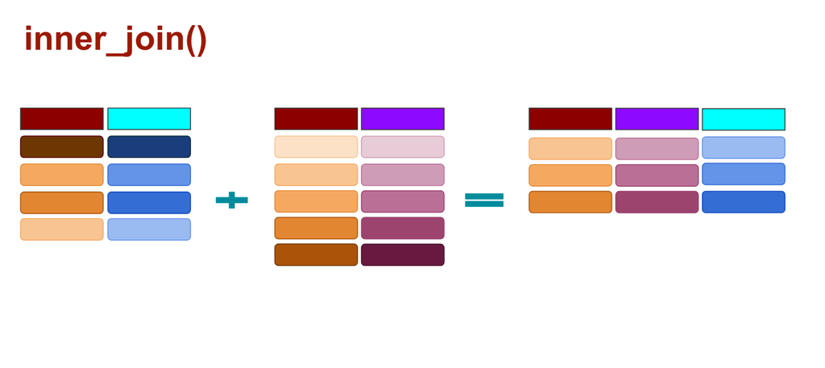

And with `inner_joins()` any rows that don’t match are dropped completely from both data sets.

```r
inner_join(left, right)
```

```
##    company     candy     location
## 1     Mars  Skittles   New Jersey
## 2  Hershey      M&Ms Pennsylvania
## 3  Cadbury   Starbar      Britain
## 4 Mondelez Toblerone  Switzerland
```

There are a [few other joins](https://dplyr.tidyverse.org/reference/join.html) that we won’t get into now, like `semi_join()` and `anti_join()`.

Whew, we went through a lot of stuff in this section.

- `gather()`
- `spread()`
- `left_join()`
- `right_join()`
- `full_join()`
- and `inner_join()`

And we learned those neat things by exploring the **murders** data set.

Wanna dig into it further and put on your criminal profiler hat?

Let’s move onto the next section where we’ll do more data wrangling and algorithm translating and maybe some serial killer tracking.

## Your turn

Challenge yourself with [these exercises](http://code.r-journalism.com/chapter-3/#section-tidying-and-joining-data) so you’ll retain the knowledge of this section.

Instructions on how to run the exercise app are on the [intro page](https://learn.r-journalism.com/en/wrangling/) to this section.